# multivariate_course

Liyenne

2024-10-29

# setup

## data import

The vegetation data consists of 12 ground cover types recorded for 80 sites:

```
## # A tibble: 10 × 13
##    code  salix Bnana dDwarf Jcomm eDwarf  gram  forb ferns   bry  lich bareGr
##    <chr> <dbl> <dbl>  <dbl> <dbl>  <dbl> <dbl> <dbl> <dbl> <dbl> <dbl>  <dbl>
##  1 N5P1    2     0.5     35     0     12  20      15     7     8   0        0
##  2 N5P2    0.5   2       20     0     60   1       8     0     2   2        0
##  3 N5P3    0     8       35     0     40   1.5    10     0     8   5        0
##  4 N5P4    6    10       15     0     65   2       4     0     6   8        0
##  5 N6P1   12     0        2     0      3   3      85    50     2   1        0
##  6 N6P2    0    16       14    22     10   9       5     0     8   2        0
##  7 N6P3    6     4       15     0     40   1       0     0    10  55        0
##  8 N6P4    0    35        7     0     24   4       3     0    40   8        0
##  9 N7P1    2     4        5     0     20   8      10     0     3   0.1      0
## 10 N7P2    8     9        3     3     16  15      35     0    70   0.1      0
## # ℹ 1 more variable: rock <dbl>
```

The environmental dataset contains 14 environmental as well as site information:

```
##      country      habitat dung_count     slope   aspect      twi      NO3
## N5P1       N       forest          1 13.033659 230.7638 6.754033 28.13450
## N5P2       N     treeline          5 19.299845 230.8719 5.742928 26.74874
## N5P3       N       tundra          8 10.142469 234.3283 6.149134 19.24343
## N5P4       N upper_tundra          0  8.895123 249.4192 7.131045 20.68432
## N6P1       N       forest          0  6.130357 306.6161 7.898840 19.20988
## N6P2       N     treeline          9  5.617383 182.0105 3.825022 27.24035
## N6P3       N       tundra         11  4.630156 239.5737 6.692544 22.87141
## N6P4       N upper_tundra          4  8.133012 275.0477 3.642921       NA
## N7P1       N       forest          0 12.537747 243.4802 5.011266 21.59282
## N7P2       N     treeline          0  5.310780 228.8327 6.121517       NA
##            NH4 PO4_corrected   wN  d15N    wC   d13C CN_ratio
## N5P1 1195.3656     3420.0790   NA    NA    NA     NA       NA
## N5P2  346.6135     4940.9589   NA    NA    NA     NA       NA
## N5P3  458.5731      187.8285 1.68  2.88 40.38 -26.57     24.0
## N5P4  787.2108      726.7686 1.32  0.47 25.43 -30.10     19.3
## N6P1 1886.6613     3718.7718   NA    NA    NA     NA       NA
## N6P2 1581.9352     7533.9079 1.75 -0.83 44.68 -28.33     25.5
## N6P3  304.4235      151.9085 1.42 -0.16 42.87 -27.54     30.2
## N6P4        NA            NA   NA    NA    NA     NA       NA
## N7P1 1535.6034      872.7753 0.87  3.17 21.98 -28.89     25.3
## N7P2        NA            NA   NA    NA    NA     NA       NA
```

# DCA & CA

A DCA on the ground cover data shows a gradient length of 2.8. This indicates an intermediate gradient length, making the choice between methods for monotonic or non-monotonic data unclear. This is likely due to the fact that the “species” data was not actually collected at the resolution of actual species but rather functional groups. The data is originates from an semi-natural experimental setting in which no clear gradient is present, however it includes sampling points across the treeline ecotone. Therefore, I choose to continue with methods for non-monotonic data.

```
##
## Call:
## decorana(veg = .)
##
## Detrended correspondence analysis with 26 segments.
## Rescaling of axes with 4 iterations.
## Total inertia (scaled Chi-square): 1.8646
##
##                        DCA1   DCA2   DCA3   DCA4
## Eigenvalues          0.4686 0.2286 0.1731 0.1887
## Additive Eigenvalues 0.4686 0.2287 0.1722 0.1883
## Decorana values      0.4873 0.2045 0.1416 0.1062
## Axis lengths         2.7671 1.7407 2.0056 1.6858
```

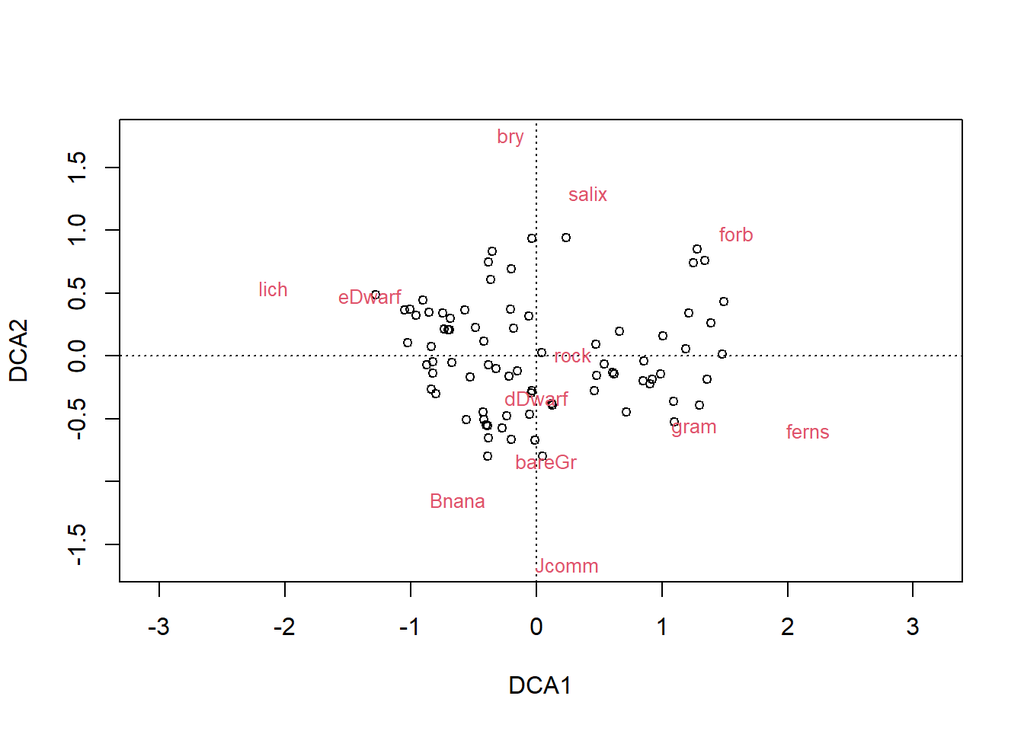

As I started out with a DCA, I also performed a CA to check whether the data shows an arch when not detrended. Plots scaled to both species and sites show a slight edge and arch effect.

```
## Call: ca(X = .)
##
## -- Model Summary --
##
##               Inertia Rank
## Total           1.865
## Unconstrained   1.865   11
##
## Inertia is scaled Chi-square
##
## -- Eigenvalues --
##
## Eigenvalues for unconstrained axes:
##    CA1    CA2    CA3    CA4    CA5    CA6    CA7    CA8    CA9   CA10   CA11
## 0.4873 0.2649 0.2228 0.1938 0.1756 0.1393 0.1306 0.1081 0.0677 0.0427 0.0319
```

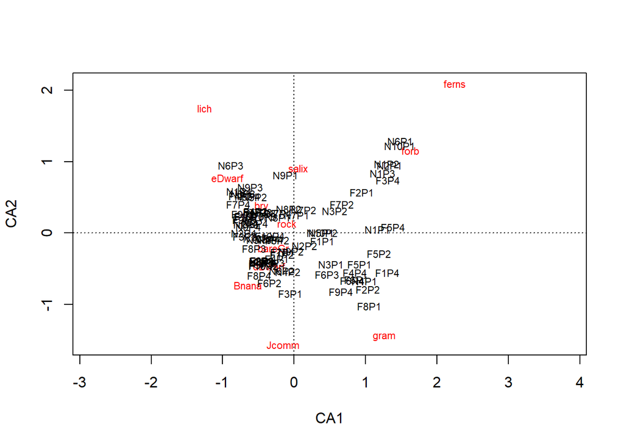

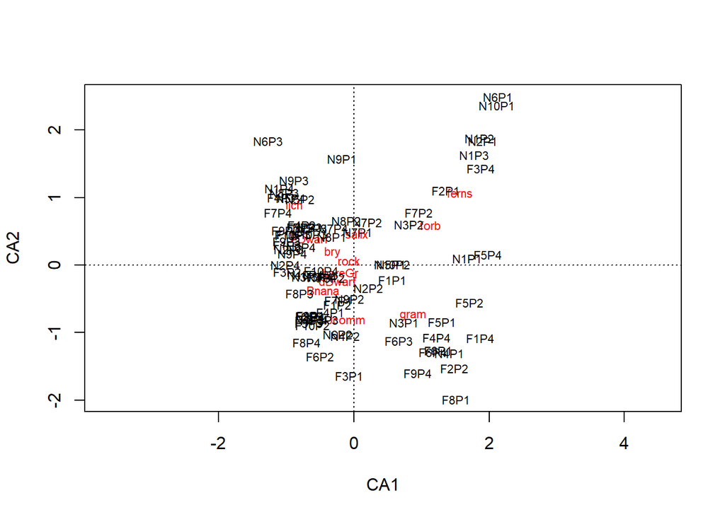

```
## Importance of components:
##                          CA1    CA2    CA3    CA4     CA5     CA6     CA7
## Eigenvalue            0.4873 0.2649 0.2228 0.1938 0.17562 0.13927 0.13058
## Proportion Explained  0.2613 0.1420 0.1195 0.1039 0.09419 0.07469 0.07003
## Cumulative Proportion 0.2613 0.4034 0.5229 0.6268 0.72098 0.79567 0.86570
##                           CA8     CA9    CA10    CA11
## Eigenvalue            0.10806 0.06768 0.04274 0.03194
## Proportion Explained  0.05795 0.03630 0.02292 0.01713
## Cumulative Proportion 0.92365 0.95995 0.98287 1.00000
```

Where “species” or in this case ground cover types tend to end up relative to one another seems to be quite similar when comparing the CA and the DCA. Specifically, the fact that lichens and graminoids occupy oposite sides of the ordination space is striking as they generally respond to reindeer grazing in contrasting ways.

# CCA

## main effects

The of primary interest in this case is the effect of the grazing regime (“country” in the model) on the community composition, while the habitats in the ecotone are likely highly influential. Therefore, I formulated a CCA with grazing regime as the main environmental variable, while controlling for the effect of “habitat”.

```r
main_cca <- cca(x ~ country + Condition(habitat), y)
permutest(main_cca)
```

```
##
## Permutation test for cca under reduced model
##
## Permutation: free
## Number of permutations: 99
##
## Model: cca(formula = x ~ country + Condition(habitat), data = y)
## Permutation test for all constrained eigenvalues
##          Df Inertia      F Pr(>F)
## Model     1 0.09015 4.5039   0.01 **
## Residual 75 1.50125
## ---
## Signif. codes:  0 '***' 0.001 '**' 0.01 '*' 0.05 '.' 0.1 ' ' 1
```

```r
summary(main_cca)
```

```
##
## Call:
## cca(formula = x ~ country + Condition(habitat), data = y)
##
## Partitioning of scaled Chi-square:
##               Inertia Proportion
## Total         1.86463    1.00000
## Conditioned   0.27323    0.14653
## Constrained   0.09015    0.04835
## Unconstrained 1.50125    0.80512
##
## Eigenvalues, and their contribution to the scaled Chi-square
## after removing the contribution of conditiniong variables
##
## Importance of components:
##                          CCA1    CA1    CA2    CA3    CA4     CA5     CA6
## Eigenvalue            0.09015 0.2834 0.2233 0.2089 0.1713 0.14824 0.13728
## Proportion Explained  0.05665 0.1781 0.1403 0.1312 0.1076 0.09315 0.08626
## Cumulative Proportion 0.05665 0.2347 0.3750 0.5063 0.6139 0.70705 0.79331
##                           CA7     CA8     CA9    CA10    CA11
## Eigenvalue            0.11002 0.10261 0.05066 0.03800 0.02763
## Proportion Explained  0.06914 0.06448 0.03184 0.02388 0.01736
## Cumulative Proportion 0.86245 0.92692 0.95876 0.98264 1.00000
##
## Accumulated constrained eigenvalues
## Importance of components:
##                          CCA1
## Eigenvalue            0.09015
## Proportion Explained  1.00000
## Cumulative Proportion 1.00000
```

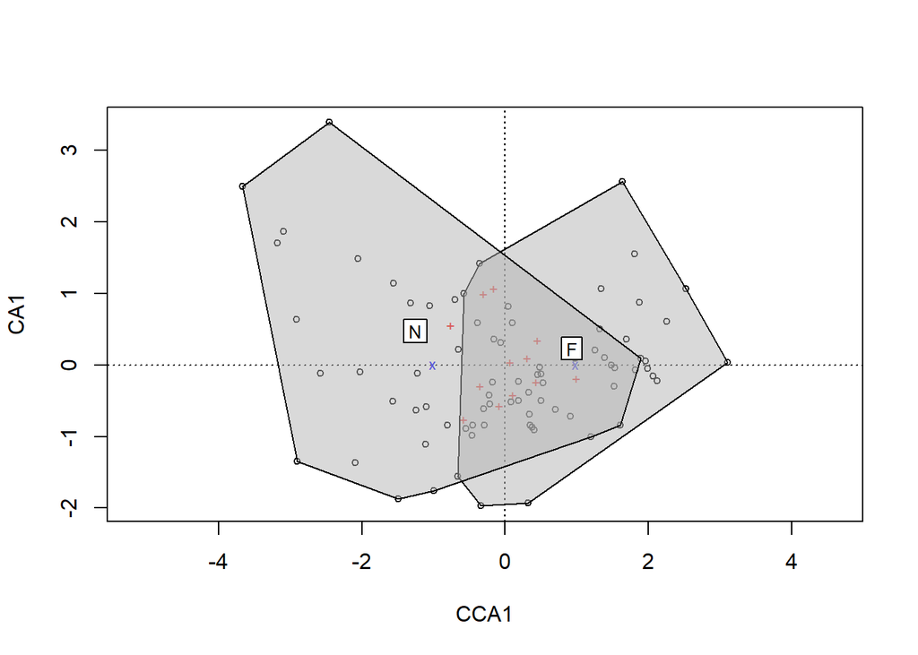

### grazing effect per habitat type

To further explor how grazing regimes affect vegetation composition in different habitat type, I performed CCAs on subsets of the data.

**Forest plots**

```r
forest_cca <- cca(a ~ country, b)
permutest(forest_cca)
```

```
##
## Permutation test for cca under reduced model
##
## Permutation: free
## Number of permutations: 99
##
## Model: cca(formula = a ~ country, data = b)
## Permutation test for all constrained eigenvalues
##          Df Inertia     F Pr(>F)
## Model     1 0.13782 1.957   0.09 .
## Residual 18 1.26766
## ---
## Signif. codes:  0 '***' 0.001 '**' 0.01 '*' 0.05 '.' 0.1 ' ' 1
```

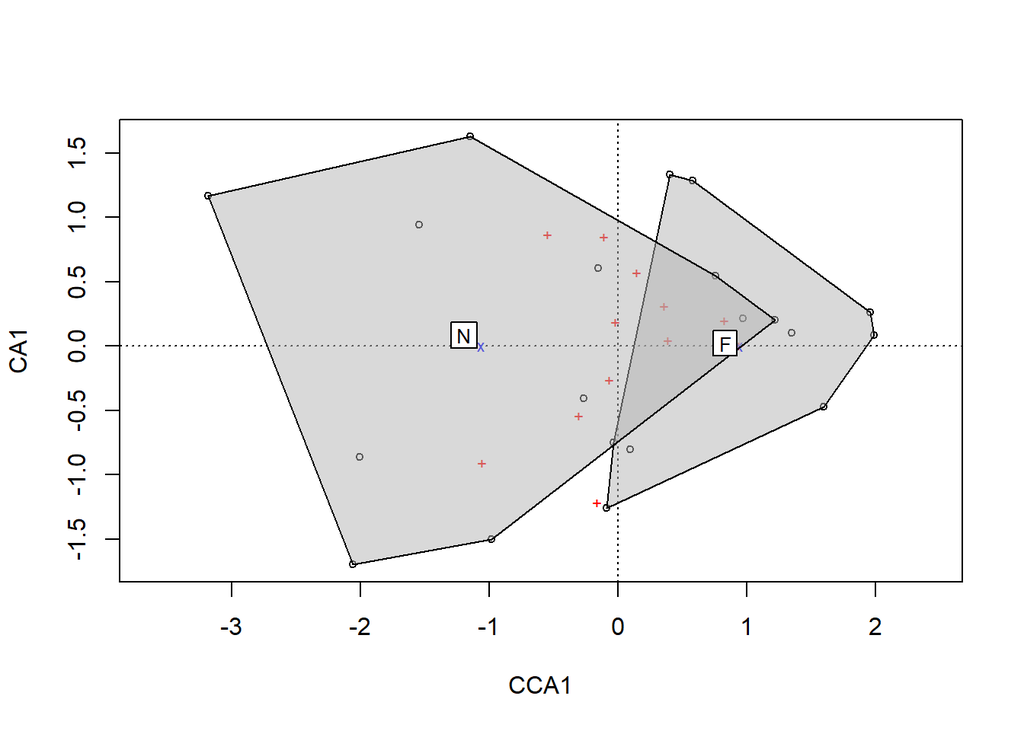

**Treeline plots**

```r
treeline_cca <- cca(a ~ country, b)
permutest(treeline_cca)
```

```
##
## Permutation test for cca under reduced model
##
## Permutation: free
## Number of permutations: 99
##
## Model: cca(formula = a ~ country, data = b)
## Permutation test for all constrained eigenvalues
##          Df Inertia      F Pr(>F)
## Model     1  0.0887 1.2874   0.29
## Residual 18  1.2403
```

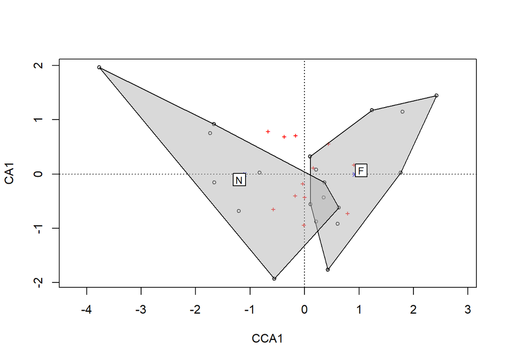

**Tundra plots**

```r
tundra_cca <- cca(a ~ country, b)
permutest(tundra_cca)
```

```
##
## Permutation test for cca under reduced model
##
## Permutation: free
## Number of permutations: 99
##
## Model: cca(formula = a ~ country, data = b)
## Permutation test for all constrained eigenvalues
##          Df Inertia      F Pr(>F)
## Model     1  0.1329 1.5582   0.16
## Residual 18  1.5353
```

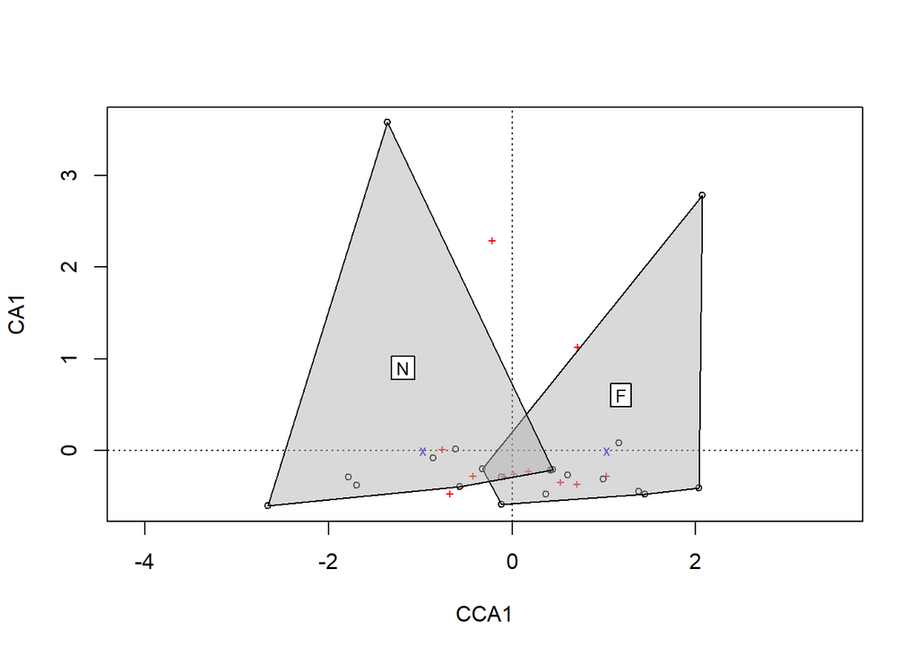

**Upper tundra plots**

```
##
## Permutation test for cca under reduced model
##
## Permutation: free
## Number of permutations: 99
##
## Model: cca(formula = a ~ country, data = b)
## Permutation test for all constrained eigenvalues
##          Df Inertia      F Pr(>F)
## Model     1 0.09149 1.5587   0.15
## Residual 18 1.05657
```

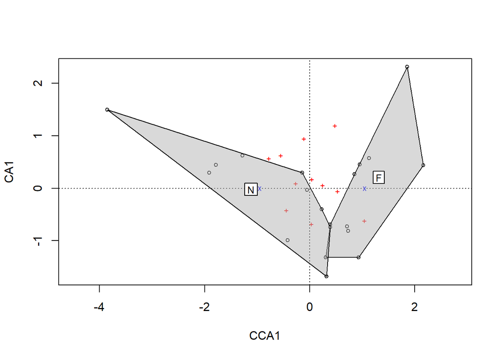

All subsets of the data appear to show clear differences between grazing regimes when only looking at isolated habitats, but the results of the CCA are never significant. I suspect that this is due to low sample sizes (i.e., 10 samples per grazing regime).

## forward selection of factors

A full model including all environmental variables is still significantly explains the variation in the dataset with an adjusted R2 of 0.265.

```
## Call: cca(formula = x ~ country + habitat + dung_count + slope + aspect +
## twi + NO3 + NH4 + PO4_corrected + wN + d15N + wC + d13C + CN_ratio, data =
## y)
##
## -- Model Summary --
##
##               Inertia Proportion Rank
## Total          1.9191     1.0000
## Constrained    0.9224     0.4807   11
## Unconstrained  0.9967     0.5193   11
##
## Inertia is scaled Chi-square
##
## -- Eigenvalues --
##
## Eigenvalues for constrained axes:
##   CCA1   CCA2   CCA3   CCA4   CCA5   CCA6   CCA7   CCA8   CCA9  CCA10  CCA11
## 0.3936 0.1650 0.0945 0.0715 0.0621 0.0491 0.0379 0.0204 0.0175 0.0078 0.0030
##
## Eigenvalues for unconstrained axes:
##     CA1     CA2     CA3     CA4     CA5     CA6     CA7     CA8     CA9    CA10
## 0.18274 0.15719 0.12810 0.12341 0.10736 0.09402 0.07469 0.05959 0.03009 0.02094
##    CA11
## 0.01852
```

```
## Permutation test for cca under reduced model
## Permutation: free
## Number of permutations: 999
##
## Model: cca(formula = x ~ country + habitat + dung_count + slope + aspect + twi + NO3 + NH4 + PO4_corrected + wN + d15N + wC + d13C + CN_ratio, data = y)
##          Df ChiSquare      F Pr(>F)
## Model    16   0.92241 2.3716  0.001 ***
## Residual 41   0.99665
## ---
## Signif. codes:  0 '***' 0.001 '**' 0.01 '*' 0.05 '.' 0.1 ' ' 1
```

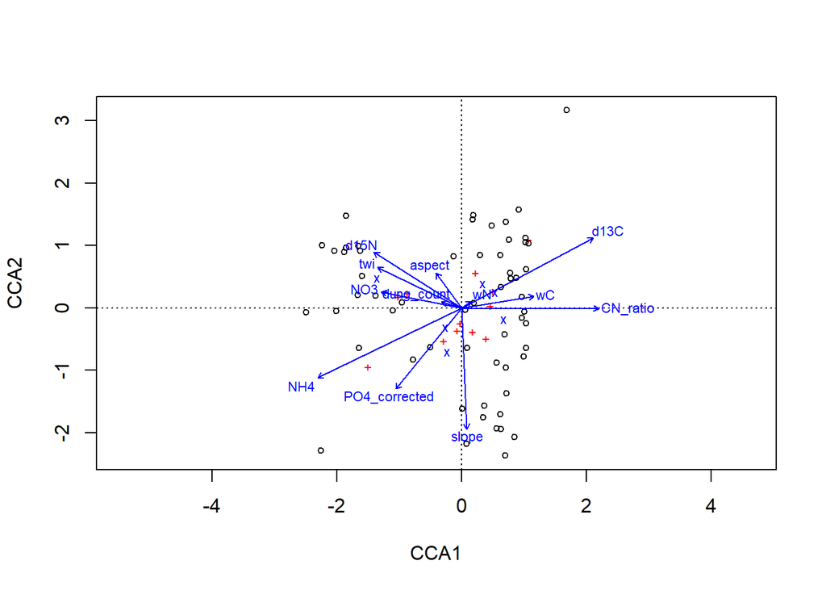

Forward selection of variables results in the inclusion of 4 significant explanatory variables (i.e., habitat, C:N ratio, ammonium, and grazing regime).

```
## Step: R2.adj= 0
## Call: x ~ 1
##
##                   R2.adjusted
## <All variables>  0.2648388326
## + habitat        0.1083888882
## + NH4            0.0959182471
## + d13C           0.0776771155
## + CN_ratio       0.0724844095
## + d15N           0.0402220350
## + PO4_corrected  0.0311979164
## + country        0.0311815717
## + twi            0.0276735728
## + wC             0.0238861581
## + NO3            0.0224346179
## + slope          0.0152636092
## + aspect         0.0083665907
## <none>           0.0000000000
## + dung_count    -0.0003760343
## + wN            -0.0016786926
##
##           Df    AIC      F Pr(>F)
## + habitat  3 310.02 3.3707  0.001 ***
## ---
## Signif. codes:  0 '***' 0.001 '**' 0.01 '*' 0.05 '.' 0.1 ' ' 1
##
## Step: R2.adj= 0.1078785
## Call: x ~ habitat
##
##                 R2.adjusted
## <All variables>   0.2648388
## + CN_ratio        0.1502479
## + NH4             0.1497571
## + d13C            0.1422714
## + country         0.1330452
## + PO4_corrected   0.1300109
## + d15N            0.1294681
## + slope           0.1282704
## + twi             0.1281379
## + wC              0.1279507
```

[output cut: 105 more lines]

```
## <All variables>   0.2648388
## + aspect          0.2587919
## + d15N            0.2537601
## + dung_count      0.2519048
## + twi             0.2503979
## + d13C            0.2478472
## + PO4_corrected   0.2476566
## + NO3             0.2461319
## <none>            0.2454809
## + wC              0.2373414
##
##          Df    AIC      F Pr(>F)
## + aspect  1 304.13 1.8642  0.076 .
## ---
## Signif. codes:  0 '***' 0.001 '**' 0.01 '*' 0.05 '.' 0.1 ' ' 1
```

```
## Call: cca(formula = x ~ habitat + CN_ratio + NH4 + country + slope + wN,
## data = y)
##
## -- Model Summary --
##
##               Inertia Proportion Rank
## Total          1.9191     1.0000
## Constrained    0.6855     0.3572    8
## Unconstrained  1.2336     0.6428   11
##
## Inertia is scaled Chi-square
##
## -- Eigenvalues --
##
## Eigenvalues for constrained axes:
##   CCA1   CCA2   CCA3   CCA4   CCA5   CCA6   CCA7   CCA8
## 0.3763 0.1364 0.0726 0.0478 0.0299 0.0149 0.0063 0.0013
##
## Eigenvalues for unconstrained axes:
##     CA1     CA2     CA3     CA4     CA5     CA6     CA7     CA8     CA9    CA10
## 0.22122 0.18551 0.15643 0.15000 0.13027 0.11926 0.08860 0.08743 0.04310 0.02642
##    CA11
## 0.02532
```

```r
sel_cca_adj <- sel_cca # get adjusted p values from the anova
sel_cca_adj$anova$`Pr(>F)` <- p.adjust(sel_cca$anova$`Pr(>F)`, method = 'holm', n = ncol(y))
sel_cca_adj$anova
```

```
##                  R2.adj Df    AIC      F Pr(>F)
## + habitat       0.10788  3 310.02 3.3707  0.014 *
## + CN_ratio      0.14960  1 308.08 3.7257  0.014 *
## + NH4           0.18561  1 306.47 3.3359  0.024 *
## + country       0.21045  1 305.48 2.7063  0.024 *
## + slope         0.23019  1 304.84 2.3258  0.250
## + wN            0.24548  1 304.35 2.1528  0.279
## <All variables> 0.26484
## ---
## Signif. codes:  0 '***' 0.001 '**' 0.01 '*' 0.05 '.' 0.1 ' ' 1
```

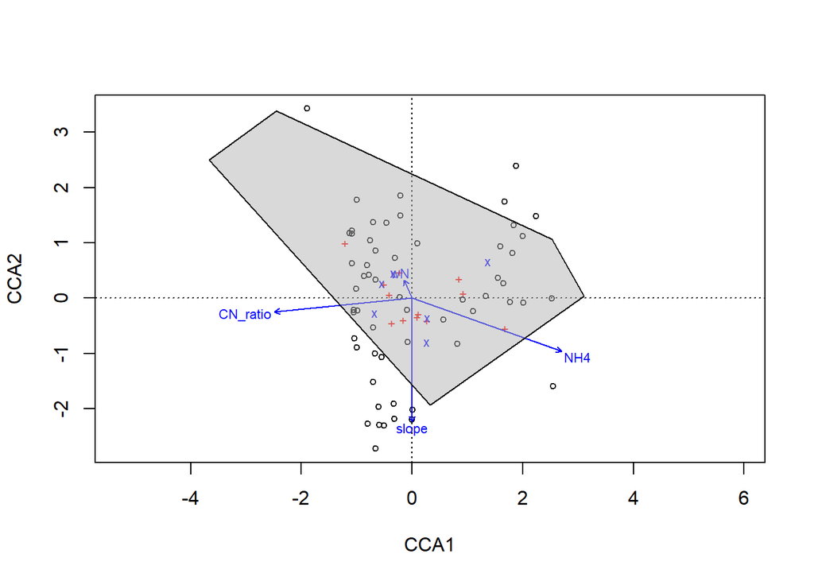

```
## Error in chull(X): finite coordinates are needed
```

```r
ordiplot(sel_cca)

ordiplot(sel_cca)
ordihull(
  main_cca,
  groups = y$country,
  draw = "polygon",
  col = "grey70",
  label = T
)
```

The factors in the model resulting from forward selection do not show colinearity

```
##     habitattreeline       habitattundra habitatupper_tundra            CN_ratio
##            1.925025            2.389912            2.158197            1.138186
##                 NH4            countryN               slope                  wN
##            1.742483            1.095059            1.317124            1.310225
```

# NMDS

An NMDS on the data shows a stress of 0.21. This value is on the edge but still somwhat acceptable, I will thus continue with my interpretation of the data.

```
## Square root transformation
## Wisconsin double standardization
## *** Best solution repeated 2 times
```

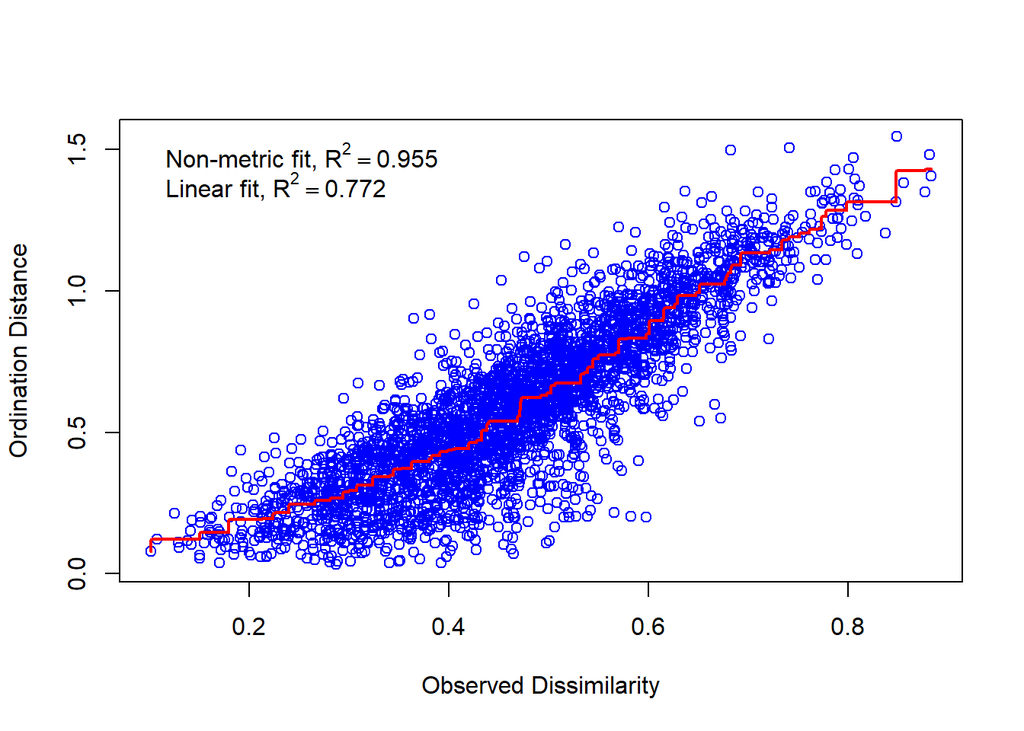

# PERMANOVA

First, I use betadisper() to test whether the dispersions (variances) of groups are different. The output shows that group variation found among habitats (forest, treeline, tundra, upper tundra) under the two grazing regimes does not differ. Meaning that the outcome of a PERMANOVA will likely be reliable.

```r
vegetation_tbl %>%
  select(salix:rock) %>%
  as.dist() %>%
  betadisper(meta_data$country_habitat) %>%
  permutest()
```

```
##
## Permutation test for homogeneity of multivariate dispersions
## Permutation: free
## Number of permutations: 999
##
## Response: Distances
##           Df  Sum Sq Mean Sq      F N.Perm Pr(>F)
## Groups     7   741.1  105.88 0.6888    999  0.684
## Residuals 72 11067.1  153.71
```

A PERMANOVA using the “adonis2” function shows that a model including an interaction between grazing regime and habitat is significant.

```
## Permutation test for adonis under reduced model
## Permutation: free
## Number of permutations: 999
##
## adonis2(formula = as.matrix(vegetation_data[, 8:19]) ~ country * habitat, data = vegetation_data, permutations = 999, method = "bray")
##          Df SumOfSqs      R2      F Pr(>F)
## Model     7   4.5762 0.27796 3.9596  0.001 ***
## Residual 72  11.8877 0.72204
## Total    79  16.4639 1.00000
## ---
## Signif. codes:  0 '***' 0.001 '**' 0.01 '*' 0.05 '.' 0.1 ' ' 1
```

```
##
## ***VECTORS
##
##                  NMDS1    NMDS2     r2 Pr(>r)
## dung_count     0.12783  0.99180 0.1396  0.016 *
## slope         -0.88539 -0.46484 0.0017  0.959
## aspect        -0.51345 -0.85812 0.2088  0.001 ***
## twi           -0.93255 -0.36105 0.1663  0.009 **
## NO3           -0.62993  0.77665 0.1333  0.018 *
## NH4           -0.92506  0.37983 0.4013  0.001 ***
## PO4_corrected -0.50571  0.86271 0.1765  0.004 **
## wN             0.03600 -0.99935 0.0032  0.910
## d15N          -0.95615 -0.29287 0.1766  0.001 ***
## wC             0.95956 -0.28152 0.0878  0.078 .
## d13C           0.98638 -0.16445 0.3297  0.001 ***
## CN_ratio       0.99904 -0.04384 0.3756  0.001 ***
## ---
## Signif. codes:  0 '***' 0.001 '**' 0.01 '*' 0.05 '.' 0.1 ' ' 1
## Permutation: free
## Number of permutations: 999
##
## ***FACTORS:
##
## Centroids:
##                       NMDS1   NMDS2
## countryF            -0.0021  0.1890
## countryN             0.0422 -0.2282
## habitatforest       -0.3246  0.1082
## habitattreeline     -0.1006 -0.0177
## habitattundra        0.2032 -0.0363
## habitatupper_tundra  0.2391 -0.0472
## transectF1          -0.1256  0.0428
## transectF10          0.3645  0.3763
## transectF2          -0.1479  0.1809
## transectF3           0.0140  0.3308
## transectF4           0.0648  0.1168
## transectF5          -0.6443  0.2378
## transectF6          -0.2490  0.1290
## transectF7           0.1702 -0.2095
## transectF8           0.1934  0.2504
```

[output cut: 8 more lines]

```
## transectN7           0.1263 -0.2800
## transectN8          -0.0433  0.2261
## transectN9           0.0605 -0.3267
##
## Goodness of fit:
##              r2 Pr(>r)
## country  0.1965  0.001 ***
## habitat  0.2685  0.001 ***
## transect 0.5241  0.003 **
## ---
## Signif. codes:  0 '***' 0.001 '**' 0.01 '*' 0.05 '.' 0.1 ' ' 1
## Permutation: free
## Number of permutations: 999
##
## 22 observations deleted due to missingness
```

**NMDS with environmental variables**

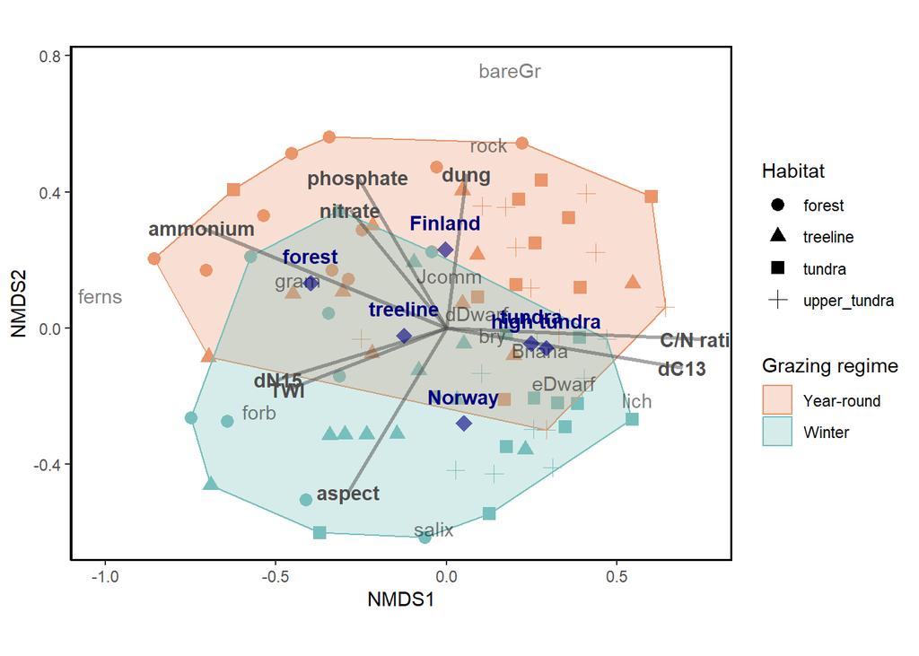

# Regression tree

Next performed a regression tree to figure out in which factors drive the differences between the two grazing regimes. I chose to exclude the aspect and slope factors from the tree model as this stems from the difference in topography between two adjacent areas, even thought the differences are consistent they are not major. the outcome shows that dung counts are the main destinguishing feature between the grazing regimes. Otherwise carbon isotopic composition plays a role.

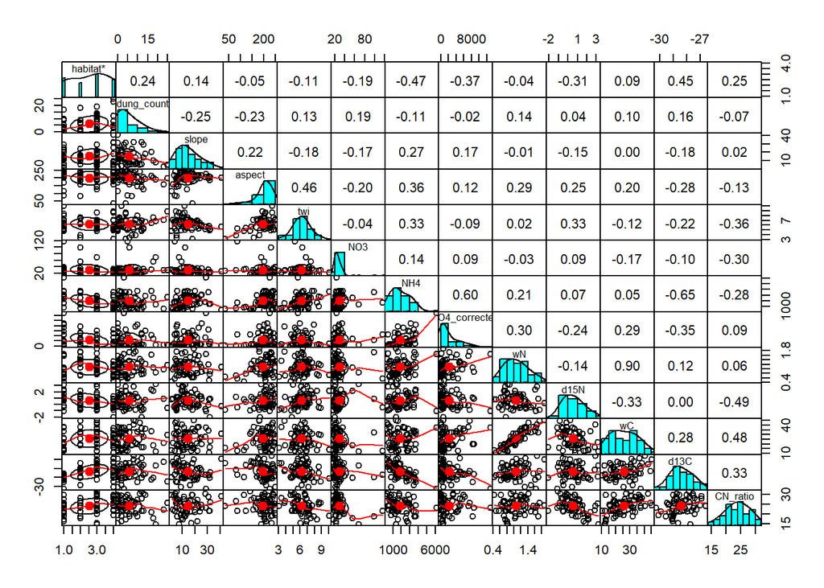

```r
pairs.panels(y[, -1], gap = 0, bg = c("red","blue")[y$country], pch = 21)
```

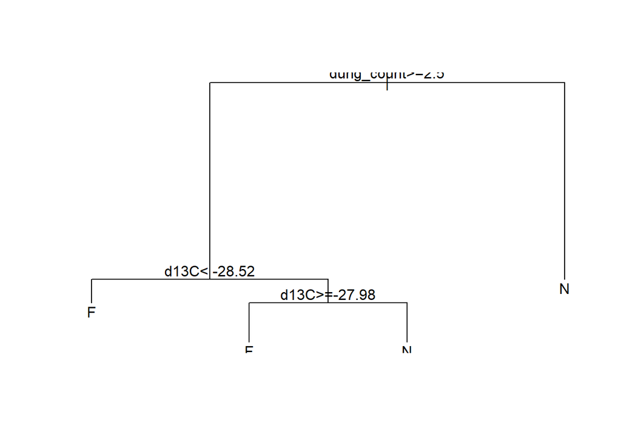

```r
tree.model <- rpart(country ~ dung_count + CN_ratio + NH4 + NO3 + d13C + d15N + PO4_corrected, data = y)

plot(tree.model)
text(tree.model)
```

# simple classification

K-means clustering shows that there are 7 clusters in the dataset. The curve of the Calinski criterion seems odd as it shows that 2 groups has a higher value than 4. As I am interested to see if data will cluster according to grazing regime I will first proceed with 2 clusters.

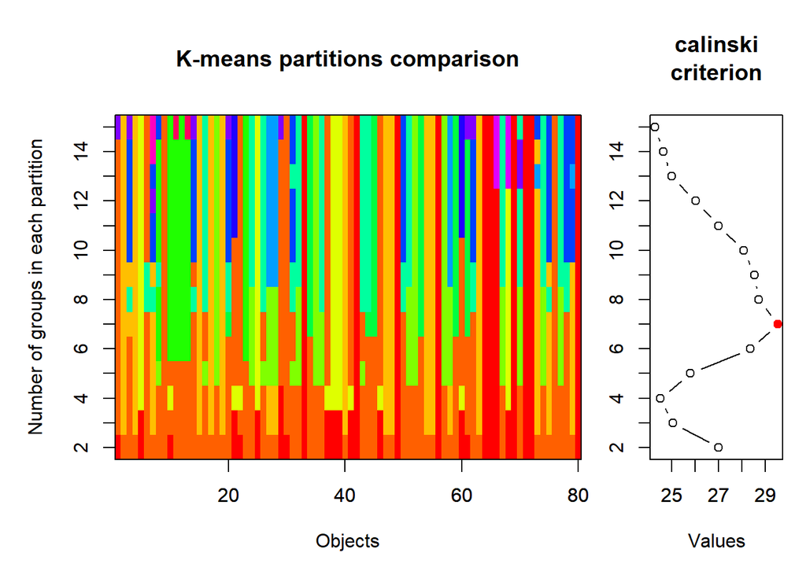

```r
kk <- cascadeKM(x, inf.gr=2,sup.gr=15)
plot(kk)
```

I tried fitting the data in 2 clusters which shows that the plots are distributed unequally between the clusters. And within each cluster an equal number of plots originating from each grazing regime. It is thus unlikely that grazing regime is a good clustering criterium.

```r
fit <- kmeans(x, 2, nstart = 50)

#cluster sizes
fit$size
```

```
## [1] 27 53
```

```r
#compare clusters to grazing regimes
table(fit$cluster, y$country)
```

```
##
##      F  N
##   1 15 12
##   2 25 28
```

Next, I tried clustering with 8 groups to see if clusters around the 4 different habitats under the two different grazing regimes would occur. If this would work perfectly, clusters should consist of 10 each as there were 10 transects in each grazing regime with 1 plot of each habitat type in each transect. However, plots seem to be somewhat randomly distributed over the clusters, showing that this combination of grazing regime and habitat does not the clustering that seems to naturally occur in the data.

```r
fit <- kmeans(x, 8, nstart = 50)

#cluster sizes
fit$size
```

```
## [1] 11  5  6 13 11 14  5 15
```

```r
#compare clusters to grazing regimes
table(fit$cluster, y$country_habitat)
```

```
##
##     Fforest Ftreeline Ftundra Fupper_tundra Nforest Ntreeline Ntundra
##   1       5         3       1             1       1         0       0
##   2       1         2       0             1       0         1       0
##   3       0         0       0             0       1         1       2
##   4       0         1       2             4       1         1       2
##   5       3         1       0             0       5         2       0
##   6       0         2       4             2       0         1       2
##   7       1         0       0             0       2         1       1
##   8       0         1       3             2       0         3       3
##
##     Nupper_tundra
##   1             0
##   2             0
##   3             2
##   4             2
##   5             0
##   6             3
##   7             0
##   8             3
```

```
## $H
## [1] 0.2088445
```